# Project Part 1

Joan Cortes - 100438579 Jose Antonio Jijon Vorbeck - 100438045 Didier Dirks - 100443386

23-12-2020

## Team Project Deliverable 1

The dataset that we have selected consists of data given by Airbnb to describe many of their locations in Madrid. In the original file, there are in total 106 variables and 20837 observations, from which some of the variables are mostly incomplete or require some data imputation.

The data that we have selected is located in the following link to the kaggle project [*Madrid AirBnB Data*](https://www.kaggle.com/rusiano/madrid-airbnb-data?select=listings_detailed.csv)

**The report will be divided into 4 main steps:**

### Data Pre-Processing

In this step, we will first focus on variables that have a high percentage of missing data ($>30%$) these variables are of no use, and we cannot perform any analysis with them, therefore we need to drop them from the dataset.

Then, there exist some other variables that have no meaning or add nothing different to the analysis, like host, listing URL, images city, country, state and other variables. We need to drop these variables as well.

We present below a graph with the percentages of missing values per variable from the complete and original dataset downloaded from Kaggle.

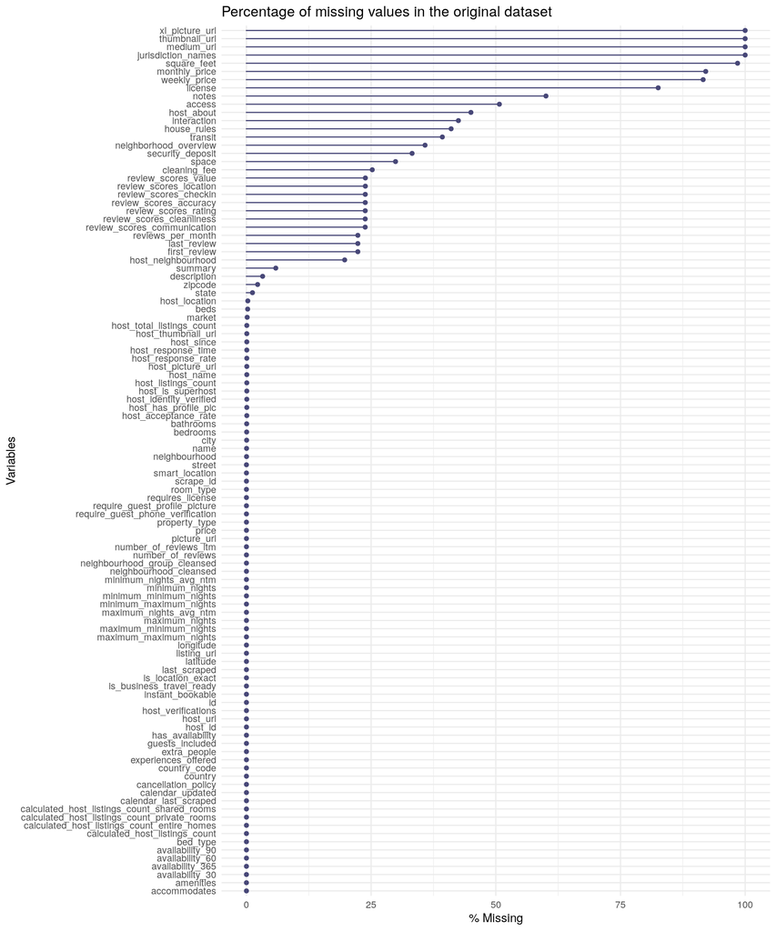

So, after verification, we can drop the following variables that have many empty (NA) values, and therefore cannot be imputed.

```r
dropVariables <- c("xl_picture_url", "thumbnail_url", "jurisdiction_names", "square_feet", "monthly_price", "weekly_price", "license", "notes", "access", "host_about", "house_rules", "transit",  "neighborhood_overview", "security_deposit", "space", "medium_url", "interaction")

X_usefulvar <- X[ , !(names(X) %in% dropVariables)]
```

But we still need to drop many variables that have no use for the analysis, for example: strings like description, experiences, picture urls and host urls.

```r
dropUseless <- c("scrape_id","listing_url","last_scraped","name","summary","description","experiences_offered","picture_url", "host_id", "host_url", "host_name", "host_since", "host_location", "host_acceptance_rate", "host_thumbnail_url", "host_picture_url", "host_neighbourhood", "host_listings_count", "host_verifications", "street", "neighbourhood", "city", "state", "market", "smart_location", "country_code", "country", "is_location_exact", "amenities", "minimum_minimum_nights","maximum_minimum_nights", "minimum_maximum_nights", "maximum_maximum_nights", "minimum_nights_avg_ntm", "maximum_nights_avg_ntm", "calendar_updated", "has_availability", "calendar_last_scraped", "number_of_reviews_ltm", "requires_license", "require_guest_profile_picture", "calculated_host_listings_count", "calculated_host_listings_count_entire_homes", "calculated_host_listings_count_private_rooms", "calculated_host_listings_count_shared_rooms")

X_clean <- X_usefulvar[ , !names(X_usefulvar) %in% dropUseless]
length(X_clean)
```

```
## [1] 44
```

After dropping all the useless variables we stay with a more significant set of variables, note that we have not done any analysis yet, only dropping variables that are of no use for further tests. We must then select the set of **quantitiative variables plus a few qualitative ones** that we are going to make plots with for visualization and furhter statistical analysis.